# DATS6101 Midterm Project: Modeling Airline Passenger Satisfaction

Jehan Bugli

2023-10-15

## Raw Data and Filtering

Responses for the ratings variables are coded as values from 1-5. However, some responses include 0, representing that the question was not applicable. Respondents that select this option for any of the ratings variables are filtered out. Fields for index number and survey ID are also removed.

The filtered dataset looks as follows:

Header rows for airline passenger dataset

| Gender | Customer.Type | Age | Type.of.Travel | Class | Flight.Distance | Inflight.wifi.service | Departure.Arrival.time.convenient | Ease.of.Online.booking | Gate.location | Food.and.drink | Online.boarding | Seat.comfort | Inflight.entertainment | On.board.service | Leg.room.service | Baggage.handling | Checkin.service | Inflight.service | Cleanliness | Departure.Delay.in.Minutes | Arrival.Delay.in.Minutes | satisfaction |
| --- | --- | --- | --- | --- | --- | --- | --- | --- | --- | --- | --- | --- | --- | --- | --- | --- | --- | --- | --- | --- | --- | --- |
| Male | Loyal Customer | 13 | Personal Travel | Eco Plus | 460 | 3 | 4 | 3 | 1 | 5 | 3 | 5 | 5 | 4 | 3 | 4 | 4 | 5 | 5 | 25 | 18 | neutral or dissatisfied |
| Male | disloyal Customer | 25 | Business travel | Business | 235 | 3 | 2 | 3 | 3 | 1 | 3 | 1 | 1 | 1 | 5 | 3 | 1 | 4 | 1 | 1 | 6 | neutral or dissatisfied |
| Female | Loyal Customer | 26 | Business travel | Business | 1142 | 2 | 2 | 2 | 2 | 5 | 5 | 5 | 5 | 4 | 3 | 4 | 4 | 4 | 5 | 0 | 0 | satisfied |
| Female | Loyal Customer | 25 | Business travel | Business | 562 | 2 | 5 | 5 | 5 | 2 | 2 | 2 | 2 | 2 | 5 | 3 | 1 | 4 | 2 | 11 | 9 | neutral or dissatisfied |
| Male | Loyal Customer | 61 | Business travel | Business | 214 | 3 | 3 | 3 | 3 | 4 | 5 | 5 | 3 | 3 | 4 | 4 | 3 | 3 | 3 | 0 | 0 | satisfied |

Summary of airline passenger dataset

|  | Gender | Customer.Type | Age | Type.of.Travel | Class | Flight.Distance | Inflight.wifi.service | Departure.Arrival.time.convenient | Ease.of.Online.booking | Gate.location | Food.and.drink | Online.boarding | Seat.comfort | Inflight.entertainment | On.board.service | Leg.room.service | Baggage.handling | Checkin.service | Inflight.service | Cleanliness | Departure.Delay.in.Minutes | Arrival.Delay.in.Minutes | satisfaction |
| --- | --- | --- | --- | --- | --- | --- | --- | --- | --- | --- | --- | --- | --- | --- | --- | --- | --- | --- | --- | --- | --- | --- | --- |
| Min | Length:95704 | Length:95704 | Min. : 7.00 | Length:95704 | Length:95704 | Min. : 31 | Min. :1.000 | Min. :1.000 | Min. :1.000 | Min. :1.000 | Min. :1.000 | Min. :1.000 | Min. :1.000 | Min. :1.000 | Min. :1.000 | Min. :1.00 | Min. :1.000 | Min. :1.000 | Min. :1.000 | Min. :1.000 | Min. : 0 | Min. : 0.00 | Length:95704 |
| Q1 | Class :character | Class :character | 1st Qu.:28.00 | Class :character | Class :character | 1st Qu.: 438 | 1st Qu.:2.000 | 1st Qu.:2.000 | 1st Qu.:2.000 | 1st Qu.:2.000 | 1st Qu.:2.000 | 1st Qu.:2.000 | 1st Qu.:2.000 | 1st Qu.:2.000 | 1st Qu.:2.000 | 1st Qu.:2.00 | 1st Qu.:3.000 | 1st Qu.:2.000 | 1st Qu.:3.000 | 1st Qu.:2.000 | 1st Qu.: 0 | 1st Qu.: 0.00 | Class :character |
| Median | Mode :character | Mode :character | Median :40.00 | Mode :character | Mode :character | Median : 867 | Median :3.000 | Median :3.000 | Median :3.000 | Median :3.000 | Median :3.000 | Median :4.000 | Median :4.000 | Median :4.000 | Median :4.000 | Median :4.00 | Median :4.000 | Median :3.000 | Median :4.000 | Median :3.000 | Median : 0 | Median : 0.00 | Mode :character |
| Mean | NA | NA | Mean :39.81 | NA | NA | Mean :1222 | Mean :2.819 | Mean :3.208 | Mean :2.878 | Mean :2.986 | Mean :3.212 | Mean :3.327 | Mean :3.455 | Mean :3.382 | Mean :3.385 | Mean :3.38 | Mean :3.636 | Mean :3.292 | Mean :3.644 | Mean :3.294 | Mean : 15 | Mean : 15.37 | NA |
| Q3 | NA | NA | 3rd Qu.:51.00 | NA | NA | 3rd Qu.:1773 | 3rd Qu.:4.000 | 3rd Qu.:4.000 | 3rd Qu.:4.000 | 3rd Qu.:4.000 | 3rd Qu.:4.000 | 3rd Qu.:4.000 | 3rd Qu.:5.000 | 3rd Qu.:4.000 | 3rd Qu.:4.000 | 3rd Qu.:4.00 | 3rd Qu.:5.000 | 3rd Qu.:4.000 | 3rd Qu.:5.000 | 3rd Qu.:4.000 | 3rd Qu.: 13 | 3rd Qu.: 13.00 | NA |
| Max | NA | NA | Max. :85.00 | NA | NA | Max. :4983 | Max. :5.000 | Max. :5.000 | Max. :5.000 | Max. :5.000 | Max. :5.000 | Max. :5.000 | Max. :5.000 | Max. :5.000 | Max. :5.000 | Max. :5.00 | Max. :5.000 | Max. :5.000 | Max. :5.000 | Max. :5.000 | Max. :1592 | Max. :1584.00 | NA |
| NA | NA | NA | NA | NA | NA | NA | NA | NA | NA | NA | NA | NA | NA | NA | NA | NA | NA | NA | NA | NA | NA | NA’s :289 | NA |

## Exploratory Data Analysis (EDA)

### EDA: Ratings variables

The dataset includes a large number of different ratings variables. Most variables have a mean response value centered around 3 points, but the distribution varies for each field.

```
## data_ratings
##
##  14  Variables      95704  Observations
## --------------------------------------------------------------------------------
## Inflight.wifi.service
##        n  missing distinct     Info     Mean      Gmd
##    95704        0        5    0.951    2.819    1.406
##
## Value          1     2     3     4     5
## Frequency  16588 24707 24757 18783 10869
## Proportion 0.173 0.258 0.259 0.196 0.114
##
## For the frequency table, variable is rounded to the nearest 0
## --------------------------------------------------------------------------------
## Departure.Arrival.time.convenient
##        n  missing distinct     Info     Mean      Gmd
##    95704        0        5    0.956    3.208     1.56
##
## Value          1     2     3     4     5
## Frequency  15212 16982 17615 24481 21414
## Proportion 0.159 0.177 0.184 0.256 0.224
##
## For the frequency table, variable is rounded to the nearest 0
## --------------------------------------------------------------------------------
## Ease.of.Online.booking
##        n  missing distinct     Info     Mean      Gmd
##    95704        0        5    0.955    2.878    1.461
##
## Value          1     2     3     4     5
## Frequency  16842 23248 23622 18733 13259
## Proportion 0.176 0.243 0.247 0.196 0.139
##
## For the frequency table, variable is rounded to the nearest 0
## --------------------------------------------------------------------------------
## Gate.location
##        n  missing distinct     Info     Mean      Gmd
##    95704        0        5    0.953    2.986    1.441
##
## Value          1     2     3     4     5
## Frequency  16066 17923 26179 22403 13133
```

[output cut: 89 more lines]

```
## Frequency   6259 10496 18997 35228 24724
## Proportion 0.065 0.110 0.198 0.368 0.258
##
## For the frequency table, variable is rounded to the nearest 0
## --------------------------------------------------------------------------------
## Cleanliness
##        n  missing distinct     Info     Mean      Gmd
##    95704        0        5    0.952    3.294    1.466
##
## Value          1     2     3     4     5
## Frequency  12121 14727 22634 25294 20928
## Proportion 0.127 0.154 0.237 0.264 0.219
##
## For the frequency table, variable is rounded to the nearest 0
## --------------------------------------------------------------------------------
```

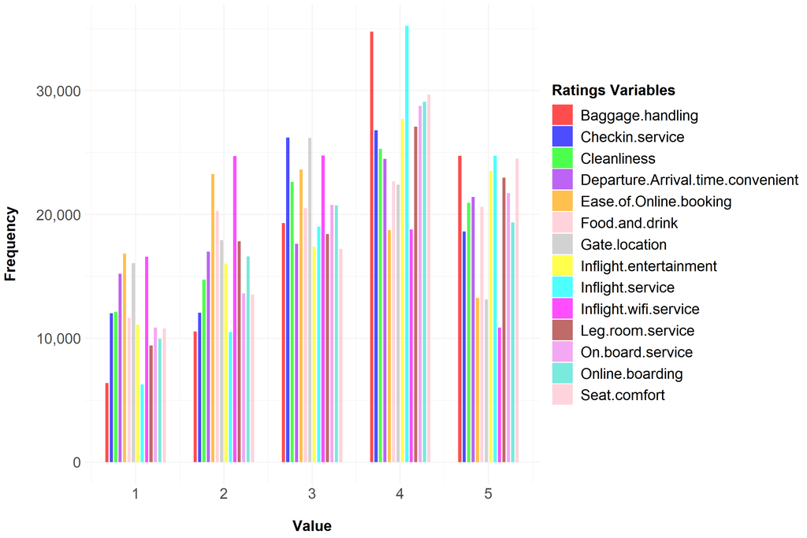

At first glance, many of the ratings included in the histogram appear to share similar frequency distributions, sparking multicollinearity concerns. Our next step to evaluate these potential relationships was to create a correlation matrix.

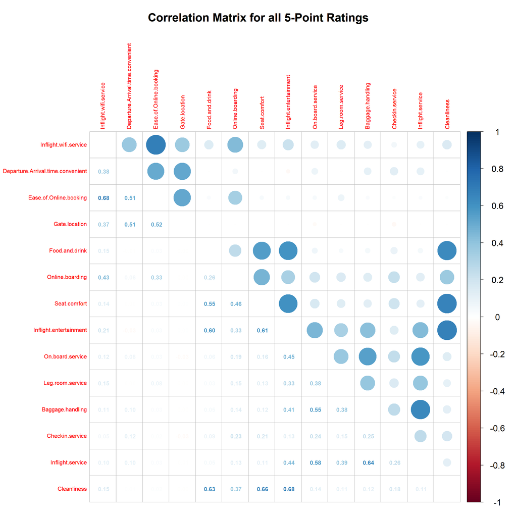

We can see from the matrix that certain ratings variables have strong positive correlations with each other. If these are included in the model without adjustments, our model may suffer a loss in reliability.

In order to avoid this issue, we elected to combine ratings variables into two groups—based on the degree of correlation—and utilize average ratings from these two groups as model inputs.

| **Ratings Group 1: Pre-Flight & Wi-Fi** |
| --- |
| In-Flight Wifi Service |
| Departure / Arrival Time |
| Ease of Online Booking |
| Gate Location |
| Online Boarding |
| —— |

| **Ratings Group 2: In-Flight & Baggage** |
| --- |
| Food and Drink |
| Seat Comfort |
| In-Flight Entertainment |
| Onboard Service |
| Leg Room Service |
| Baggage Handling |
| Check-In Service |
| In-Flight Service |
| Cleanliness |
| —— |

The two consolidated ratings variables share a weak positive correlation (correlation coefficient = **0.1814536**), indicating that they can be jointly included in our model without violating the collinearity assumption.